# AI Memory and Switching Costs: Pilot Survey Results

Descriptive Analysis of Prolific Sample

April 03, 2026

```
## N after cleaning: 206
## Cleaned data saved. Rows: 206  Cols: 118
```

```
##
## === Demand Suppression (Q13 - Q14) ===
## Mean = $1.21, SD = $6.70, p = 0.0108
##
## === Portability Recovery (Q15 - Q14) ===
## Mean = $2.46, SD = $6.85, p = 0.0000
##
## === Effective Portability (phi_eff) ===
## Median = 1.00, Mean = 1.02, N = 50
##
## === Consistency Check ===
## W2 >= W3 >= W4: 74.3%
## W2 >= W4: 96.0%
##
## Sensitivity analysis saved.
```

```
## === Regression: Demand Suppression on Usage Frequency ===
##
## Call:
## lm(formula = demand_suppression ~ freq_num + age_group + gender +
##     education, data = df_reg)
##
## Residuals:
##     Min      1Q  Median      3Q     Max
## -47.218  -1.822  -0.663   1.771  36.716
##
## Coefficients:
##                                          Estimate Std. Error t value Pr(>|t|)
## (Intercept)                                3.0928     2.3510   1.315   0.1899
## freq_num                                   0.5015     0.4485   1.118   0.2649
## age_group25-34                            -2.8802     1.8670  -1.543   0.1246
## age_group35-44                            -2.8091     1.8319  -1.533   0.1268
## age_group45-54                            -5.0729     1.9361  -2.620   0.0095
## age_group55-64                            -2.4036     2.2753  -1.056   0.2921
## age_group65+                              -3.7004     2.5100  -1.474   0.1421
## genderNon-binary                          -2.4695     5.3040  -0.466   0.6420
## genderWoman                               -0.4675     0.9813  -0.476   0.6343
## educationDoctoral or professional degree   2.7389     4.2932   0.638   0.5243
## educationHigh school or less              -3.1110     1.4833  -2.097   0.0373
## educationMaster's degree                  -0.1216     1.5195  -0.080   0.9363
## educationSome college                      1.0660     1.1541   0.924   0.3569
##
## (Intercept)
## freq_num
## age_group25-34
## age_group35-44
## age_group45-54                           **
## age_group55-64
## age_group65+
## genderNon-binary
## genderWoman
## educationDoctoral or professional degree
## educationHigh school or less             *
## educationMaster's degree
## educationSome college
## ---
## Signif. codes:  0 '***' 0.001 '**' 0.01 '*' 0.05 '.' 0.1 ' ' 1
##
## Residual standard error: 6.616 on 189 degrees of freedom
## Multiple R-squared:  0.08359,    Adjusted R-squared:  0.0254
## F-statistic: 1.437 on 12 and 189 DF,  p-value: 0.1523
```

# 1 Introduction

This report summarizes the pilot survey for a study on AI memory and platform lock-in. The survey elicits beliefs about AI memory, willingness to accept (WTA) compensation for memory erasure, and willingness to pay (WTP) for a competing AI assistant under varying data portability scenarios. These measures map directly onto a theoretical model of switching costs driven by accumulated personalization data.

The pilot was fielded on Prolific with N = 206 respondents who completed the survey in a median of 5.2 minutes. All WTP/WTA questions were asked within-subjects (the full experiment will use a between-subjects design).

# 2 Sample Description

## 2.1 Demographics

Sample Demographics

| Variable | Category | N | % |
| --- | --- | --- | --- |
| age_group | 18-24 | 18 | 8.7 |
|  | 25-34 | 51 | 24.8 |
|  | 35-44 | 69 | 33.5 |
|  | 45-54 | 39 | 18.9 |
|  | 55-64 | 17 | 8.3 |
|  | 65+ | 12 | 5.8 |
| gender | Man | 109 | 52.9 |
|  | Non-binary | 2 | 1.0 |
|  | Woman | 95 | 46.1 |
| education | Bachelor’s degree | 96 | 46.6 |
|  | Doctoral or professional degree | 3 | 1.5 |
|  | High school or less | 27 | 13.1 |
|  | Master’s degree | 26 | 12.6 |
|  | Some college | 54 | 26.2 |
| occupation | Creative & Design | 12 | 5.8 |
|  | Education | 11 | 5.3 |
|  | Finance | 13 | 6.3 |
|  | Healthcare | 14 | 6.8 |
|  | Management & Executive | 18 | 8.7 |
|  | Marketing & Sales | 16 | 7.8 |
|  | Other (please specify) | 61 | 29.6 |
|  | Research & Academic | 10 | 4.9 |
|  | Software & IT | 43 | 20.9 |
|  | Student | 8 | 3.9 |
| industry | Education | 16 | 7.8 |
|  | Finance & Insurance | 19 | 9.2 |
|  | Government | 3 | 1.5 |
|  | Healthcare | 17 | 8.3 |
|  | Manufacturing | 10 | 4.9 |
|  | Media & Entertainment | 13 | 6.3 |
|  | Other (please specify) | 56 | 27.2 |
|  | Retail & E-commerce | 22 | 10.7 |
|  | Technology | 50 | 24.3 |

## 2.2 AI Platform Usage

Platform usage: personal, work, and paid subscriptions

| Platform | Personal Use N | Personal Use % | Work Use N | Work Use % | Paid N | Paid % |
| --- | --- | --- | --- | --- | --- | --- |
| ChatGPT (OpenAI) | 159 | 77.2 | 101 | 49.0 | 39 | 18.9 |
| Google Gemini | 120 | 58.3 | 52 | 25.2 | 8 | 3.9 |
| Microsoft Copilot | 57 | 27.7 | 45 | 21.8 | 5 | 2.4 |
| Claude (Anthropic) | 41 | 19.9 | 25 | 12.1 | 8 | 3.9 |
| Grok (xAI) | 28 | 13.6 | 8 | 3.9 | 5 | 2.4 |
| Meta AI (Facebook / Instagram / WhatsApp) | 22 | 10.7 | 3 | 1.5 | 0 | 0.0 |
| Perplexity | 14 | 6.8 | 6 | 2.9 | 4 | 1.9 |
| DeepSeek | 6 | 2.9 | 1 | 0.5 | 0 | 0.0 |
| Character.AI | 6 | 2.9 | 0 | 0.0 | 0 | 0.0 |

ChatGPT dominates personal use (77%) and work use. 28% of respondents pay for any AI subscription. The mean respondent uses 2.3 platforms, and 65% qualify as multihomers (2+ platforms).

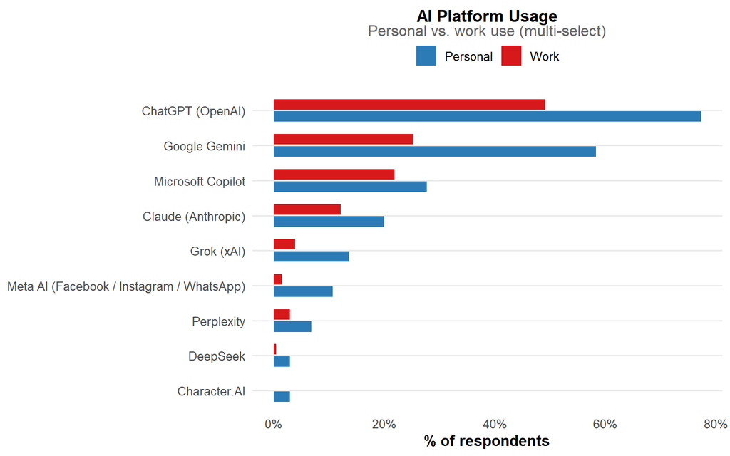

AI Platform Usage (Personal vs. Work)

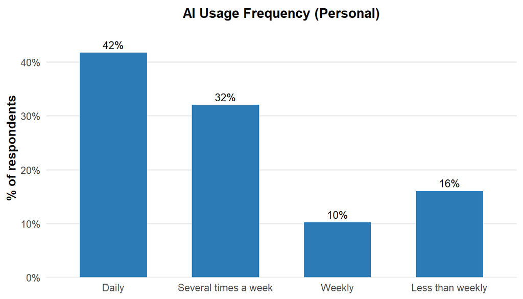

Usage Frequency

Regarding multihoming frequency (Q4): Always (1%), Never (24%), Often (12%), Rarely (28%), Sometimes (35%).

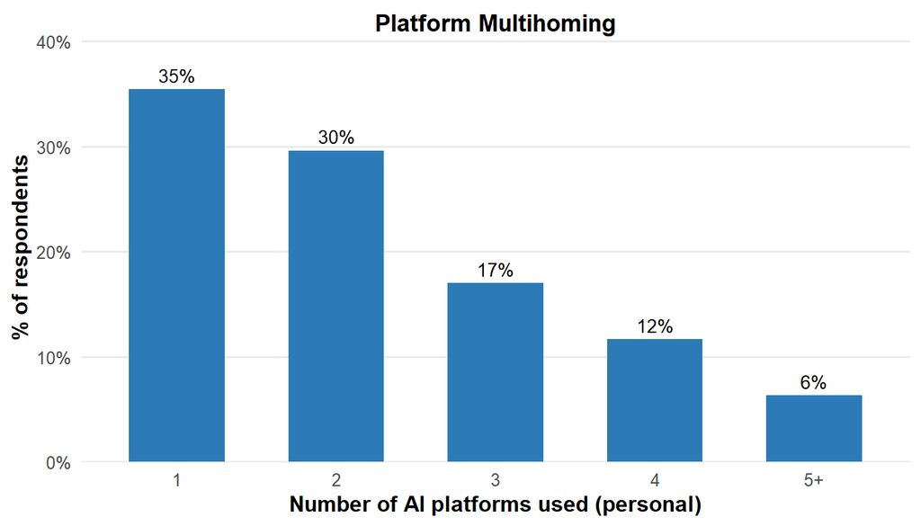

Number of AI Platforms Used

## 2.3 Ad-Free Valuation

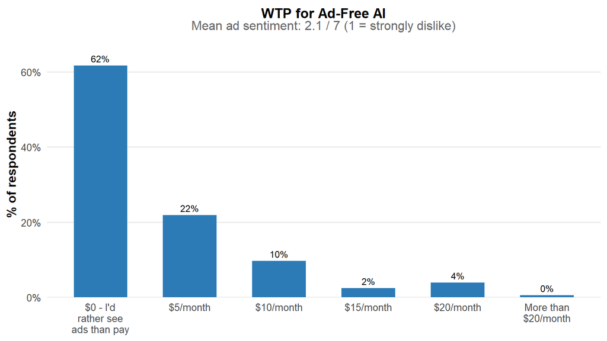

WTP for Ad-Free AI

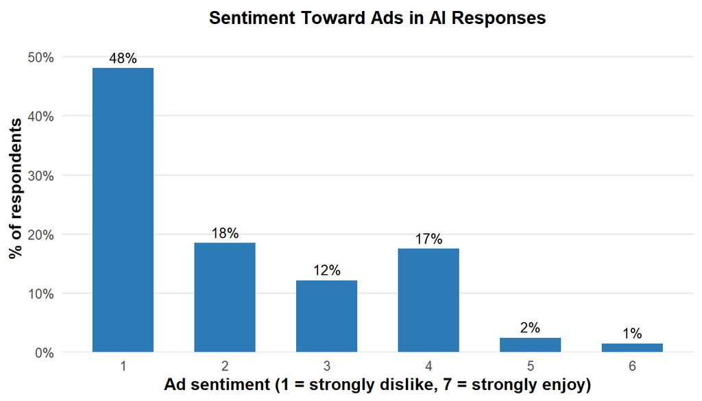

Ad Sentiment

Mean ad sentiment is 2.1 on a 1–7 scale (1 = strongly dislike). The majority (62%) would rather see ads than pay, despite strongly disliking ads.

# 3 Memory Beliefs and Switching Perceptions

## 3.1 Memory Awareness

Memory Awareness Crosstab

| AI Remembers? | Reviewed Memories? | N | % |
| --- | --- | --- | --- |
| I’m not sure | I didn’t know I could | 8 | 3.9 |
| I’m not sure | No | 26 | 12.6 |
| I’m not sure | Yes | 3 | 1.5 |
| No | I didn’t know I could | 6 | 2.9 |
| No | No | 10 | 4.9 |
| No | Yes | 9 | 4.4 |
| Yes | I didn’t know I could | 16 | 7.8 |
| Yes | No | 67 | 32.5 |
| Yes | Yes | 61 | 29.6 |

70% of respondents believe their AI remembers them. Only 35% have reviewed their AI’s memories, and 15% did not know they could.

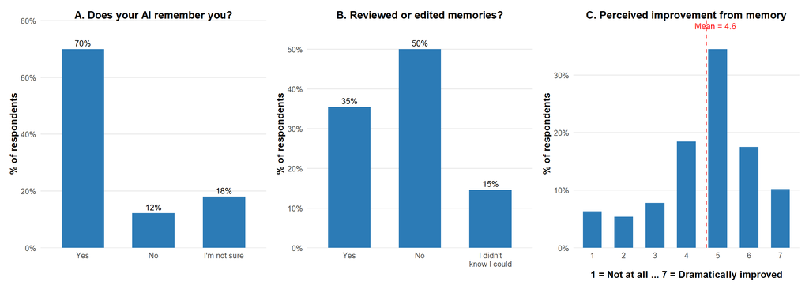

Memory Beliefs Overview

Perceived improvement from memory averages 4.6 / 7 (SD = 1.6), indicating moderate perceived value.

## 3.2 Switching Losses

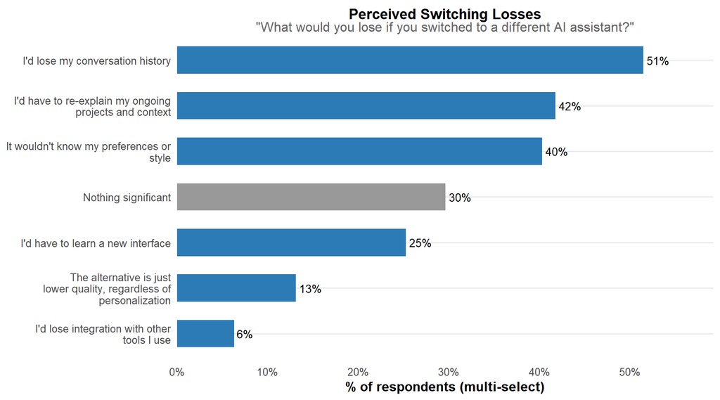

Perceived Switching Losses

## 3.3 Time to Re-Personalize

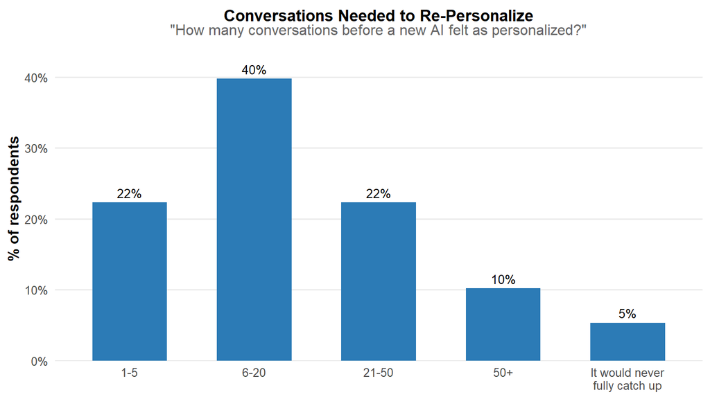

Conversations Needed to Re-Personalize

5% believe a new assistant would *never* fully catch up—an extreme form of perceived lock-in.

# 4 Valuation Results

## 4.1 Survey-to-Model Mapping

Mapping: Survey Variables to Model Notation

| Survey Q | Variable | Model | Description |
| --- | --- | --- | --- |
| Q12 | wta_memory_erasure | W1 | WTA to erase ChatGPT memory |
| Q13 | wtp_claude_no_strings | W2 | WTP for Claude (memory intact) |
| Q14 | wtp_claude_with_erasure | W4 | WTP for Claude (memory erased) |
| Q15 | wtp_claude_with_transfer | W3 | WTP for Claude (memory transferred) |
| Q13 - Q14 | demand_suppression | W2 - W4 | Demand suppression from memory |
| Q15 - Q14 | portability_recovery | W3 - W4 | Demand recovered by portability |
| 1-(Q13-Q15)/(Q13-Q14) | phi_eff | phi_eff | Effective portability share |

## 4.2 WTA for Memory Erasure

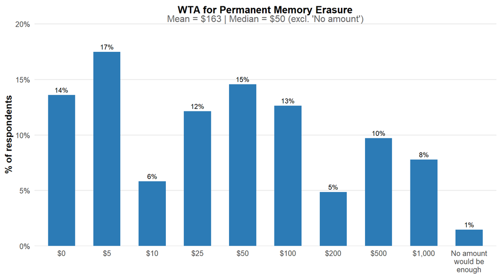

WTA for Permanent Memory Erasure

Valuation Summary Statistics

| Measure | N | % at $0 | Mean | Median | SD | IQR |
| --- | --- | --- | --- | --- | --- | --- |
| WTA memory erasure (W1) | 203 | 13.8 | 162.7 | 50 | 284.8 | 95 |
| WTP Claude no strings (W2) | 204 | 55.4 | 4.7 | 0 | 7.3 | 5 |
| WTP Claude with erasure (W4) | 204 | 66.7 | 3.9 | 0 | 8.2 | 5 |
| WTP Claude with transfer (W3) | 204 | 49.0 | 6.1 | 5 | 8.2 | 10 |

## 4.3 WTP Across Scenarios

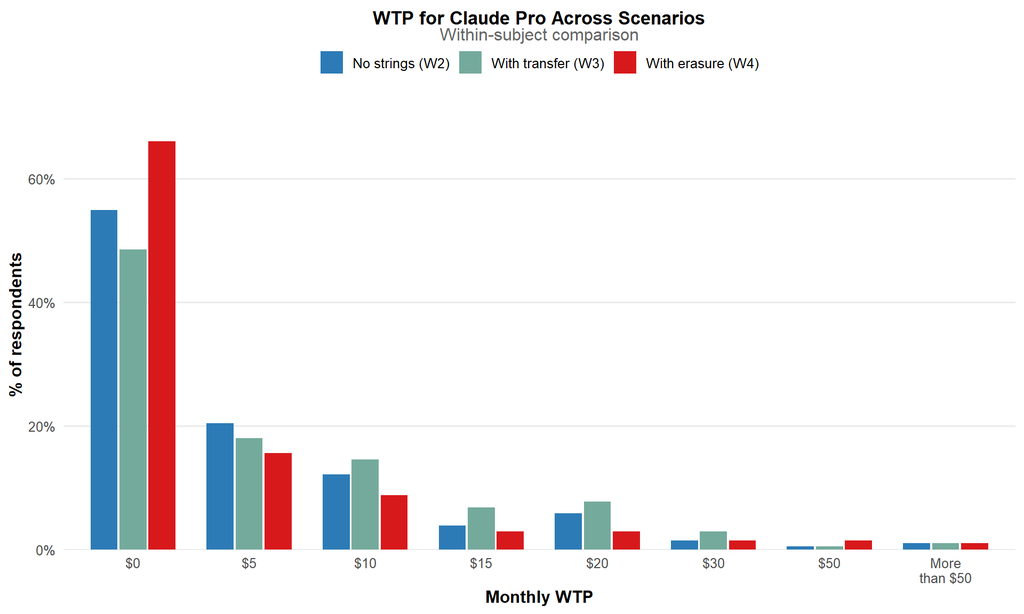

WTP for Claude Pro: Within-Subject Comparison

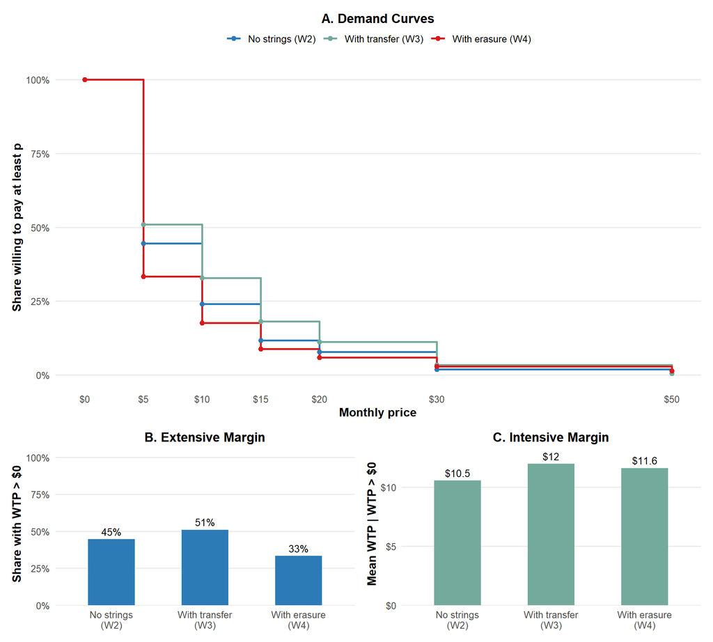

Demand Curves and Margin Decomposition

The demand curves show the gap between scenarios: the vertical distance between the “no strings” and “with erasure” curves represents demand suppression, while the distance from “with transfer” to “with erasure” represents portability recovery.

## 4.4 Demand Suppression and Portability

**Demand suppression** (Q13 $-$ Q14): mean = $1.21, SD = $6.7, *t*-test against zero: *p* = 0.0108.

**Portability recovery** (Q15 $-$ Q14): mean = $2.46, SD = $6.85, *t*-test against zero: *p* = 6.91e-07.

**Effective portability** ($\hat{\varphi}_{eff}$): median = 1, mean = 1.02 (N = 50 with nonzero denominator).

**Consistency check**: 74.3% of respondents have W2 $\geq$ W3 $\geq$ W4 (theory-consistent ordering); 96% have W2 $\geq$ W4.

Sensitivity: Censoring Assumptions

| Scenario | WTA Mean | WTP No Strings | WTP Erasure | WTP Transfer |
| --- | --- | --- | --- | --- |
| Baseline (excl. censored) | 162.7 | 4.7 | 3.9 | 6.1 |
| Censor ‘No amount’ at $1,000 | 174.9 | 5.4 | 4.6 | 6.8 |
| Censor ‘No amount’ at $2,000 | 189.4 | 5.4 | 4.6 | 6.8 |

## 4.5 WTA by Perceived Improvement

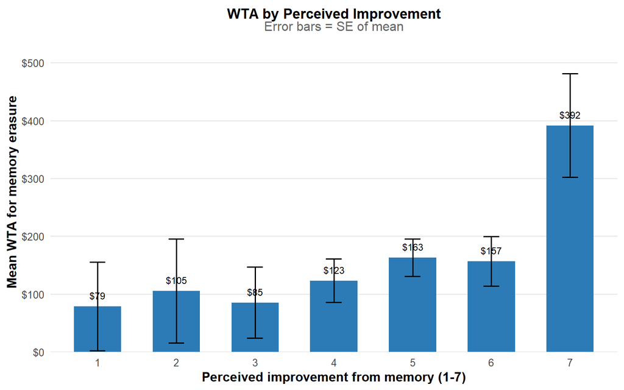

Mean WTA by Perceived Improvement Level

# 5 Mechanisms

## 5.1 Demand Suppression and Usage Intensity

If memory and usage are complements ($u_{tm} > 0$), heavier users should exhibit greater demand suppression. We regress (Q13 $-$ Q14) on usage frequency, controlling for demographics.

OLS: Demand Suppression on Usage Frequency + Demographics

| Term | Estimate | SE | t | p |
| --- | --- | --- | --- | --- |
| (Intercept) | 3.093 | 2.351 | 1.315 | 0.190 |
| freq_num | 0.501 | 0.448 | 1.118 | 0.265 |
| age_group25-34 | -2.880 | 1.867 | -1.543 | 0.125 |
| age_group35-44 | -2.809 | 1.832 | -1.533 | 0.127 |
| age_group45-54 | -5.073 | 1.936 | -2.620 | 0.010 |
| age_group55-64 | -2.404 | 2.275 | -1.056 | 0.292 |
| age_group65+ | -3.700 | 2.510 | -1.474 | 0.142 |
| genderNon-binary | -2.470 | 5.304 | -0.466 | 0.642 |
| genderWoman | -0.468 | 0.981 | -0.476 | 0.634 |
| educationDoctoral or professional degree | 2.739 | 4.293 | 0.638 | 0.524 |
| educationHigh school or less | -3.111 | 1.483 | -2.097 | 0.037 |
| educationMaster’s degree | -0.122 | 1.519 | -0.080 | 0.936 |
| educationSome college | 1.066 | 1.154 | 0.924 | 0.357 |

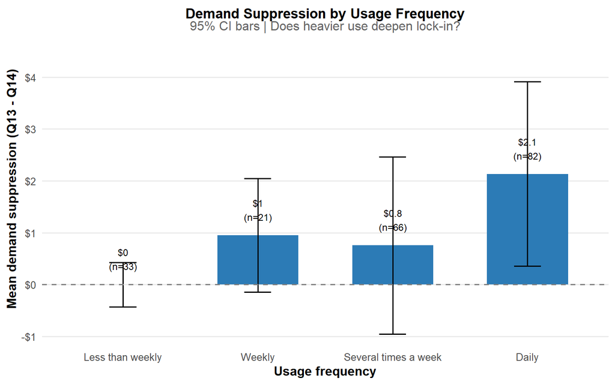

Demand Suppression by Usage Frequency

## 5.2 Memory Awareness vs. Perceived Improvement

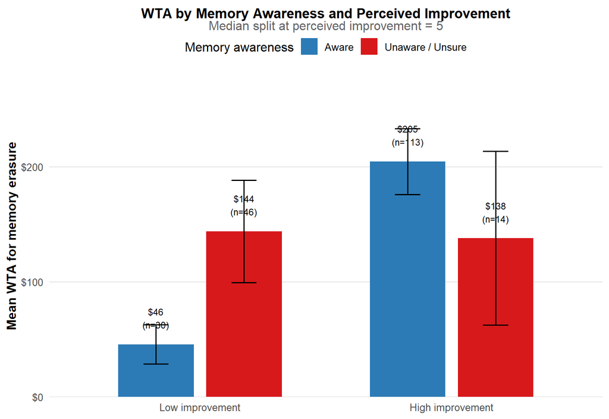

WTA by Memory Awareness and Perceived Improvement

## 5.3 Concentration Beliefs vs. Actual Multihoming

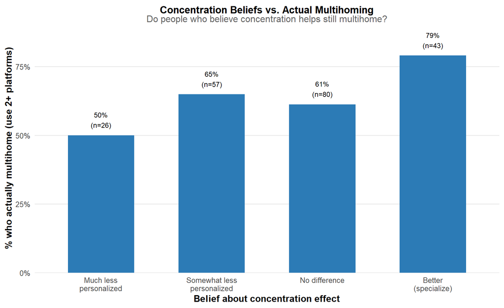

Concentration Beliefs vs. Actual Multihoming

# 6 Design Calibration

This section summarizes findings relevant to the full experiment design.

## 6.1 BDM Price Range

The WTA distribution for memory erasure (Q12) suggests:

- 14% accept $0 (no value from memory)
- The 25th–75th percentiles span $5 to $100
- 1.5% say “no amount” (right-censored)

**Recommendation**: A BDM price list from $0 to $100 in $5 increments would capture the bulk of the distribution while maintaining incentive compatibility. Consider a broader range ($0–$500) for the WTA question if budget permits.

## 6.2 Stratification Candidates

Covariates Predicting WTA (p < 0.10)

| Term | Estimate | SE | t | p |
| --- | --- | --- | --- | --- |
| frequency_ordered.L | 120.572 | 48.011 | 2.511 | 0.013 |
| ai_remembersYes | -114.900 | 60.649 | -1.895 | 0.060 |
| perceived_improvement_num | 34.197 | 15.892 | 2.152 | 0.033 |

## 6.3 Preliminary Effect Sizes

For power calculations:

- **Demand suppression** (Q13 $-$ Q14): Cohen’s $d$ = 0.181
- **Portability recovery** (Q15 $-$ Q14): Cohen’s $d$ = 0.36

These within-subject effect sizes serve as upper bounds for the between-subjects design. The between-subjects experiment should plan for effect sizes approximately 50–70% of these values.

# 7 Appendix

## 7.1 Survey Completion Time

Completion Time (minutes)

| Min. | 1st Qu. | Median | Mean | 3rd Qu. | Max. |
| --- | --- | --- | --- | --- | --- |
| 2.2 | 4.2 | 5.2 | 6 | 6.9 | 25.3 |

## 7.2 Awareness of Claude Import Feature

6.8% were aware of Claude’s ChatGPT memory import feature before the survey. Among those aware (N = 14), 3 had actually used it.

## 7.3 Forecast: Quality After Erasure

Mean forecast quality after one month of re-use: 3.9 / 7 (1 = substantially worse, 7 = substantially better). Respondents expect moderate degradation but not catastrophic loss.

## 7.4 Forecast: Transfer Fidelity

Mean expected transfer fidelity: 56%. Distribution: 0%: 20, 100%: 29, 25%: 33, 50%: 56, 75%: 68.